# HSB2 Data Analysis

Jennifer Harrist

## Introduction

We will begin by loading in our data and setting *SES* as a factor.

## Analysis

Reading is a foundational tool that is required in all content areas. As such, the instruction of mathematics has changed from being able to compute an algorithm to reading and decoding word problems in order to construct the algorithm needed. Therefore, It is assumed that a student’s reading ability will be positively related to their math scores.

Hypothesis 1 is proposed: H1: Students’ reading score will positively influence to their math scores.

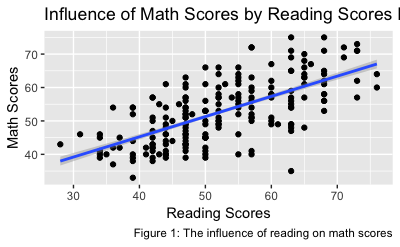

```r
p1 <- ggplot(hsb2, aes(x = read, y = math))
p2 <- p1 + geom_point() +
  stat_smooth(method = "lm", fullrange = TRUE, level = 0.70) +
  labs(x = "Reading Scores",
       y = "Math Scores",
       title = "Influence of Math Scores by Reading Scores by SES ",
       caption = "Figure 1: The influence of reading on math scores")
p2
```

In considering H1, a positive relationship exists between reading and math scores, as seen in Figure 1. Therefore, hypothesis 1 is supported. As reading scores increase, math scores increase.

Where reading ability can have a positive influence on math scores, it is assumed that differences in SES will influence overall relationship between reading and math scores.

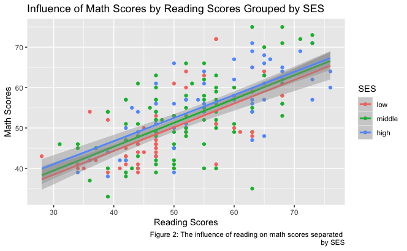

```r
p3 <- ggplot(hsb2, aes(x = read, y = math, color = SES))
p4 <- p3 + geom_point() +
  stat_smooth(method= "lm", level = 0.70, fullrange = TRUE) +
  labs(x = "Reading Scores",
       y = "Math Scores",
       title = "Influence of Math Scores by Reading Scores Grouped by SES ",
       caption = "Figure 2: The influence of reading on math scores separated
       by SES")
p4
```

## Conclusions

A positive relationship for math by reading scores is evident, regardless of student SES. Figure 2 indicates that while a positive relationship exists in all SES categories, there are different ability levels between the groups, though the difference between them is small. Ability levels are evident between the SES groups, with low SES having the lowest scores.